# Progetto Web and Social Mining

1 Data Retrival  
1.1 Twitter API  
1.2 Reddit API  
1.3 Repubblica articles’scraping  
1.4 Comparison, cluster, networks

1 Descriptive analysis  
2.1 Twitter  
2.2 Reddit  
2.3 Reoubblica  
2.4 Comparison, cluster, networks

3. Repubblica articles’scraping  
3.1 Data retrival  
3.2 Descriptive analysis  
3.3 Text cleaning and text mining  
3.4 Comparison, cluster, networks

1 Data retrival

```r
tw <- search_tweets(q = "affitti|affitto",n = 2000,type="recent",include_rts = F,lang="it")

twPIU <- make.tweet.df(tw)
```

1.2 Reddit API  
Downloading threads andcomments in the last month

```r
RDt<-find_thread_urls(keywords = "affitti", sort_by = "comments", period = "month")

RDt<- RDt %>% mutate(ID=1:nrow(RDt),.before=1)
```

2 Descriptive analysis  
2.1 Twitter

Hashtags analysis  
This is the code to analyse the most common hashtags etc.

We want to see most used hashtag inside the tweets containing the words “affitti” and “affitto”. Then we group the hashtags to see the most used in descending order and how many times they appeared

```r
dfHash %>% group_by(hash1) %>% summarise(nn=n()) %>% arrange(-nn) %>% slice_head(n=10)
```

```
## # A tibble: 10 × 2
##    hash1           nn
##    <chr>        <int>
##  1 affitti         44
##  2 milano          17
##  3 locazioni       10
##  4 bologna          8
##  5 casa             8
##  6 notizie          5
##  7 affittibrevi     4
##  8 economia         4
##  9 fiaip            4
## 10 inter            4
```

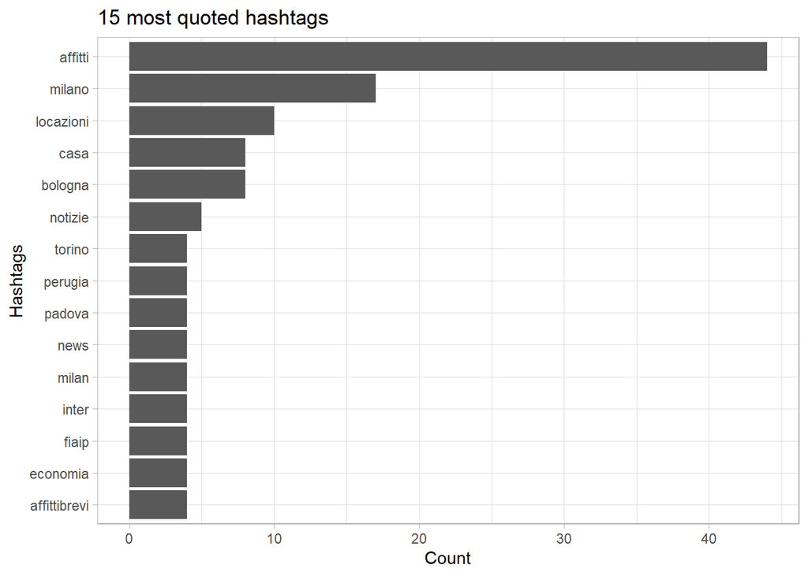

```r
as_tibble(unlist(twPIU$hashtags)) %>% select(hashtag = 1) %>% filter(!is.na(hashtag))%>%
  mutate(hashtag = tolower(hashtag)) %>% group_by(hashtag) %>% summarise(nn= n()) %>% arrange(-nn) %>% top_n(10)%>%
  ggplot(aes(x=reorder(hashtag,nn),y=nn)) + geom_bar(stat="identity") + xlab("Hashtags") + ylab("Count") + coord_flip() +
  theme_light() + ggtitle("15 most quoted hashtags")
```

Most followed users

We want to see the most famous twitter accounts that covered our topic. So we retrieved the most followed accounts that made tweets containing “affitto” or “affitti”.

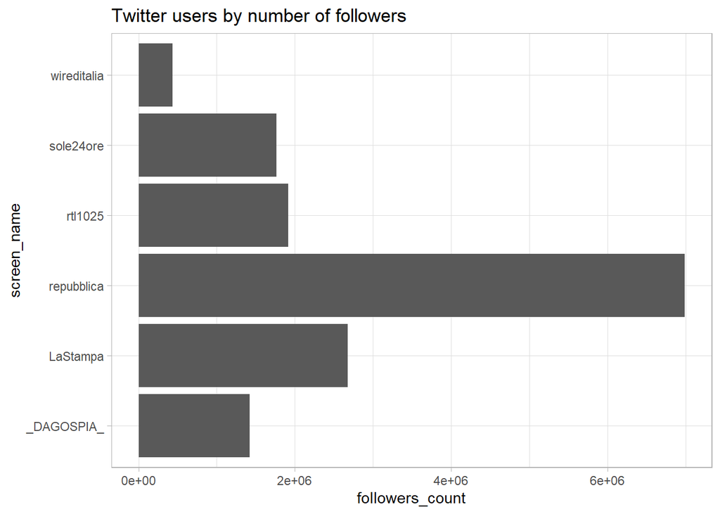

```r
a %>% ggplot(aes(x = screen_name, y = followers_count), colour="red") + geom_bar(stat="identity") +
  theme_light()+ coord_flip()+ ggtitle("Twitter users by number of followers")
```

Number of tweets per day

We plot the time series of tweets from the 1th of October to the 20th to see if there are days due to for examples some ““important”” news about our topic

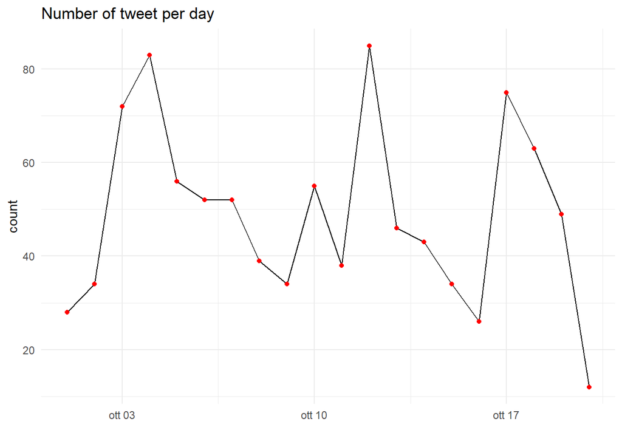

```r
time_series2%>% ggplot(aes(x=day,y=n,group=1)) + geom_line() + geom_point(color="red") + theme_minimal() + xlab("") + ylab("count")+ ggtitle("Number of tweet per day")
```

Engagement analysis

We want to see the tweets the were most popular amongst our dataset. We can see the three tweets that have the most engagement (engagement.tot = retweet_count+favorite_count)

```r
head(eng,3)
```

```
## # A tibble: 3 × 5
##   created_at          screen_name     full_text                  engag…¹ engag…²
##   <dttm>              <chr>           <chr>                        <dbl>   <int>
## 1 2022-10-06 12:43:09 statidigrazia   "Cmq l’emergenza affitti …  1.97      1244
## 2 2022-10-15 17:33:43 anikeatable     "Visto che sono nei grupp…  0.0444     665
## 3 2022-10-06 19:00:40 CristinaMolendi "Pago le tasse regolarmen…  0.119      516
## # … with abbreviated variable names ¹engagement.rate, ²engagement.tot
```

```r
head(eng$full_text,3)
```

```
## [1] "Cmq l’emergenza affitti per studenti fuorisede (anche lavoratori, ma studenti in particolare) nelle grandi città è allucinante. Non si trovano stanze o se le trovi i prezzi sono anormali, proprietari di casa che su fb ti rispondono “se non te lo puoi permettere non venire a roma”"
## [2] "Visto che sono nei gruppi di affitti da un po' mi chiedo come mai non ci siano controlli di alcun tipo in questo ambito. Ci sono propietari che affittano a studenti locali al limite della norma, non parlo tanto del prezzo (tanto è risaputo e per quanto faccia schifo mettere in &gt;"
## [3] "Pago le tasse regolarmente quindi posso fare questo tweet. Per quanto tempo un proprietario di un immobile deve essere ostaggio, o oggetto di ricatto, da parte di un inquilino che non vuole andarsene ? È una vergogna. Neppure fosse casa sua. \n#affitti #locazioni @Palazzo_Chigi"
```

Verified users

We wanted to see if our topic was covered by imortant sources. We checked if in our dataset there were tweets by verified users

```r
head(veri,5)
```

```
## # A tibble: 5 × 3
##   created_at          screen_name    full_text
##   <dttm>              <chr>          <chr>
## 1 2022-10-19 16:35:48 AleSans1       "Nel caos degli annunci di affitti online …
## 2 2022-10-18 07:51:04 EasyInve       "A #Bologna anche il rettore dell'universi…
## 3 2022-10-17 18:31:09 gazzettamodena "Affitti in nero agli studenti,1700 casi s…
## 4 2022-10-17 12:19:19 _DAGOSPIA_     "LEGGI A MISURA DI TRUFFA. MI-JENA GABANEL…
## 5 2022-10-17 11:39:15 idealista_it   "L’inflazione cresce a settembre, quanto a…
```

Mentioned users.

Than we check the most mentioned users among our tweets

```r
dfMent <- dfMent %>% filter(!is.na(ment))
c<-dfMent %>% group_by(ment)
dfMent%>% group_by(ment)%>%summarise(a=n())%>%arrange(-a)%>%slice_head(n=10)
```

```
## # A tibble: 10 × 2
##    ment                a
##    <chr>           <int>
##  1 repubblica         22
##  2 Dario_Donato       21
##  3 Palazzo_Chigi      11
##  4 CristinaMolendi     9
##  5 Sargans2            7
##  6 SirDistruggere      7
##  7 bioccolo            6
##  8 fattoquotidiano     6
##  9 ritaHardata         6
## 10 BeppeSala           5
```

# Reddit

## Number of post or comments on Reddit per day

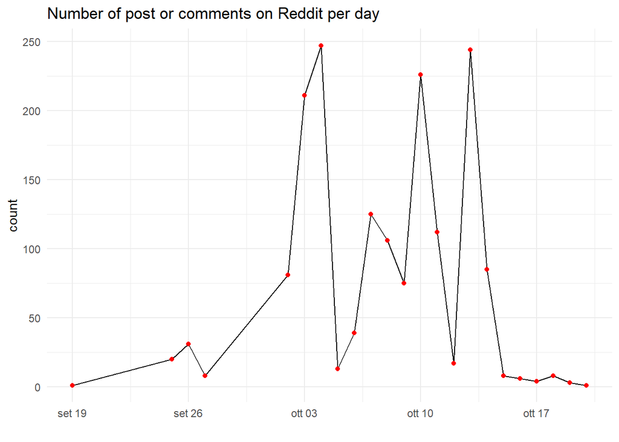

```r
time_seriesR%>% ggplot(aes(x=day,y=n,group=1)) + geom_line() + geom_point(color="red") + theme_minimal() + xlab("") + ylab("count")+ ggtitle("Number of post or comments on Reddit per day")
```

## Most upvotes posts on Reddit

```r
upvotesR%>% drop_na(title)%>%slice(1:3)
```

```
## # A tibble: 3 × 5
##   author      date       title                                     text  upvotes
##   <chr>       <chr>      <chr>                                     <chr>   <dbl>
## 1 Karjumi     2022-10-10 "Ho raccolto alcuni dati sulla mia ricer… "Dop…    1304
## 2 YahyaJ      2022-10-07 "[TUTORIAL] Come fare soldi online e in … "Imm…     949
## 3 Pineta1000m 2022-10-03 "Emergenza affitti a Bologna: agli stude… ""        502
```

```r
upvotesR%>% drop_na(title)%>%slice(1:3)%>%select(title)
```

```
## # A tibble: 3 × 1
##   title
##   <chr>
## 1 "Ho raccolto alcuni dati sulla mia ricerca di case a Roma in due mesi e ne ho…
## 2 "[TUTORIAL] Come fare soldi online e in fretta mettendo in affitto immobili c…
## 3 "Emergenza affitti a Bologna: agli studenti offerto un divano per 350 euro al…
```

## Most upvotes comments on Reddit

```r
upvotesR%>% dplyr::filter(is.na(title)) %>%select(author,date,text,upvotes)%>%slice(1:3)
```

```
## # A tibble: 3 × 4
##   author            date       text                                      upvotes
##   <chr>             <chr>      <chr>                                       <dbl>
## 1 TaiPeler          2022-10-07 "Istruzioni poco chiare, ora ho 4 ragazz…     562
## 2 MisterErrore      2022-10-03 "Menomale che il salotto è ampLio"            374
## 3 MaBrutoBrutoBruto 2022-10-13 "/u/Karjumi complimenti sei famoso!!\n\n…     290
```

```r
upvotesR%>% dplyr::filter(is.na(title)) %>%select(author,date,text,upvotes)%>%slice(1:3)%>%select(text)
```

```
## # A tibble: 3 × 1
##   text
##   <chr>
## 1 "Istruzioni poco chiare, ora ho 4 ragazzi di 23 anni fuorisede in cantina che…
## 2 "Menomale che il salotto è ampLio"
## 3 "/u/Karjumi complimenti sei famoso!!\n\nLo stagista di wired ti ha contattato…
```

## Most commented posts on Reddit

```r
ndf%>%select(titoli,diff)%>%slice(1:3)
```

```
##                                                                                                 titoli
## 1                    Emergenza affitti a Bologna: agli studenti offerto un divano per 350 euro al mese
## 2 Ho raccolto alcuni dati sulla mia ricerca di case a Roma in due mesi e ne ho fatto un\031infografica
## 3                 La Generazione Z si sfoga su TikTok e Reddit contro il caro affitti a Milano e Roma.
##   diff
## 1  454
## 2  344
## 3  335
```

# Cleaning text

We remove metions, hashatags, numbers and punctations from our tweets. Then we put everything lowercase.

Three examples of tweets before the cleaning

```r
cleanTXT[,1]
```

```
## [1] "Affitti a Milano: per un monolocale a Brera si pagano 1.400 euro al mese, 1.000 a City Life https://t.co/KS3IfVKOB5"
## [2] "A Bologna amico sta cercando appartamento da affittare con 3 camere da letto, gli affitti vanno da 1300 euro/mese in su quando fino a 2 anni fa erano a 800/900."
## [3] "Affitti: oltre 6 milioni di euro per integrare i canoni di locazione. Melasecche: \"Continuiamo a lavorare per garantire il diritto alla casa\"\nhttps://t.co/g4nOPbwKww https://t.co/Tr5JHKbsGw"
```

The same tweets after the cleaning

```r
cleanTXT[,2]
```

```
## [1] "affitti a milano per un monolocale a brera si pagano euro al mese a city life"
## [2] "a bologna amico sta cercando appartamento da affittare con camere da letto gli affitti vanno da euro mese in su quando fino a anni fa erano a"
## [3] "affitti oltre milioni di euro per integrare i canoni di locazione melasecche continuiamo a lavorare per garantire il diritto alla casa"
```

We want to perform multi-words identification since we want to merge the most common bigram and trigram… in our dataset

```r
visNGram(x = twPIU$txt.c,ngrI = 2,ngrF = 3,nn = 30,show.table = T,save.xlsx = T, xlsx.name = "exMWords.xlsx")

twCLEAN$col3<-corMultWord(x = twPIU$txt.c,xlsx.file = "exMWords.xlsx")
```

```r
visingram<-twCLEAN%>%dplyr::select(col2,col3)%>%slice(c(226,138,991))
```

```r
visingram[,2]
```

```
## [1] "affitti a milano per un monolocale a brera si pagano euro al mese a city life"
## [2] "a bologna amico sta cercando appartamento da affittare con camere da letto gli affitti vanno da euro mese in su quando fino a anni fa erano a"
## [3] "affitti oltre milioni di euro per integrare i canone_locazione melasecche continuiamo a lavorare per garantire il diritto alla casa"
```

Then we visualize the three tweets after applying the a named-entity recognition….

```r
multWordPOS(x = txt, model = "italian", n = Inf, save.xlsx = T,xlsx.name = "txt_c_pos.xlsx")

twCLEAN$col4 <- corMultWord(x = txt, xlsx.file = "txt_c_pos.xlsx")
```

```r
multiword<-twCLEAN%>%dplyr::select(col3,col4)%>%slice(c(226,138,991))
```

```r
multiword[,2]
```

```
## [1] "affitti a milano per un monolocale a brera si pagano euro al mese a city_life"
## [2] "a bologna amico sta cercando appartamento da affittare con camere da letto gli affitti vanno da euro mese in su quando fino a anni fa erano a"
## [3] "affitti oltre milioni di euro per integrare i canone_locazione melasecche continuiamo a lavorare per garantire il diritto alla casa"
```

```r
mod<-udpipe_download_model("italian-isdt")
modello<-udpipe_load_model(mod)
```

Then we perform a lemmatization

```r
#lemmatizazione + eliminare le stopword italiane
dfCorpusLem <- lemmaUDP(x = twCLEAN$col4,
                        model = modello,
                        stopw = tm::stopwords("it"),
                        userstopw = c("affitto","affitti","NA"))



txtLem <- dfCorpusLem %>%
  filter(!is.na(dfCorpusLem$lemma) & dfCorpusLem$STOP == FALSE & upos %in% c("ADJ","NOUN")) %>%
  select(doc_id, lemma) %>%
  group_by(doc_id = as.numeric(doc_id)) %>%
  summarise(txtL = paste(lemma, collapse = " "))
```

```r
lemmaudp<-twCLEAN%>%dplyr::select(col4,col5)%>%slice(c(226,138,991))
```

```r
lemmaudp[,2]
```

[output not shown]

# Vectorization

create a Term-Document matrix, una matrice in cui ti dice per ogni parola in quali tweet è presente

```r
corp <- Corpus(VectorSource(twCLEAN$col5))
tdm <- TermDocumentMatrix(corp)
inspect(tdm)
```

```
## <<TermDocumentMatrix (terms: 2565, documents: 1076)>>
## Non-/sparse entries: 8012/2751928
## Sparsity           : 100%
## Maximal term length: 20
## Weighting          : term frequency (tf)
## Sample             :
##           Docs
## Terms      1051 1061 129 134 16 227 271 623 641 78
##   anno        0    0   0   1  1   0   0   0   0  1
##   caro        0    0   0   0  0   0   1   0   0  0
##   casa        0    0   0   0  0   0   0   0   0  0
##   città       0    0   0   1  0   1   1   0   0  0
##   comune      0    0   0   0  0   0   0   0   0  0
##   euro        0    0   0   0  0   0   0   0   0  0
##   mese        0    0   0   0  0   0   0   0   0  0
##   milano      0    0   0   0  0   0   0   0   0  0
##   prezzo      0    0   0   0  1   0   0   0   0  0
##   studente    0    0   0   0  0   0   0   0   0  0
```

```r
m.tdm <- as.matrix(tdm)
```

## Dataframe with words frequencies

```r
dfWords <- data.frame(word=rownames(m.tdm),freq=rowSums(m.tdm))
rownames(dfWords) <- NULL
dfWords %>% arrange(-freq) %>% head(10)
```

```
##        word freq
## 1      casa  186
## 2      euro  124
## 3      caro   99
## 4    prezzo   97
## 5  studente   89
## 6     città   89
## 7      anno   84
## 8    milano   74
## 9    comune   55
## 10     mese   54
```

TF-IDF words are assigned a weight that reflects the importance of the word in a document in a collection

```r
tdm.idf <- weightTfIdf(tdm)
m.tdm.idf <- as.matrix(tdm.idf)
dftermsidf <- data.frame(word=rownames(m.tdm.idf),freq=rowSums(m.tdm.idf))
rownames(dftermsidf) <- NULL
dftermsidf %>% arrange(-freq) %>% head(15)
```

```
##             word     freq
## 1           casa 64.50753
## 2           caro 59.60994
## 3           euro 57.31135
## 4         prezzo 56.32668
## 5       studente 48.97556
## 6         milano 46.63244
## 7          città 42.93041
## 8       bolletta 39.73207
## 9         comune 37.23957
## 10          anno 36.39418
## 11          nero 34.56205
## 12        stella 33.35570
## 13 universitario 31.36919
## 14          alto 30.42228
## 15      problema 30.04620
```

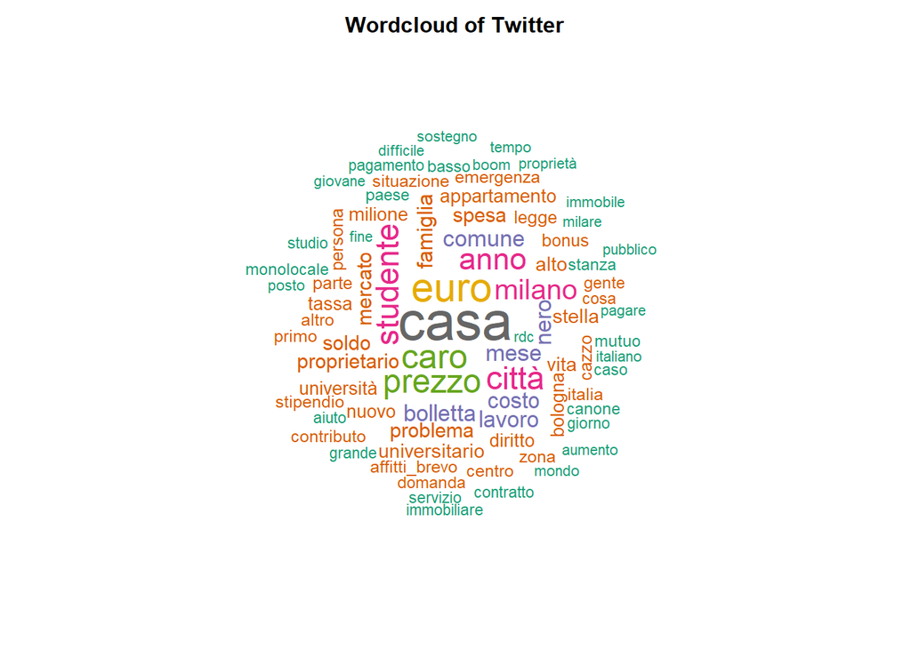

```r
dfWordsTW <- dfWords

par(mar=c(0,0,0,0))
wordcloud(words = dfWordsTW$word, # vector of words (here lemmas)
          freq = dfWordsTW$freq, # vector with word frequencies
          scale = c(2.5,0.5), # word size range
          # 2.5 is the size of the most frequent words
          # 0.5 is the size of the least frequent words
          max.words = 80, # maximum number of words to display
          random.order = FALSE, # if FALSE the most important words are in the centre
          colors = brewer.pal(8, "Dark2")) # vector of colours to be used
text(0.5,1,"Wordcloud of Twitter",cex=1,font = 2)
```

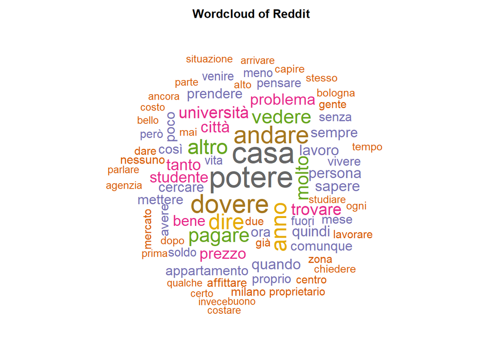

```r
par(mar=c(0,0,0,0))
wordcloud(words = dfWordsRed$word, # vector of words (here lemmas)
          freq = dfWordsRed$freq, # vector with word frequencies
          scale = c(2.5,0.5), # word size range
          # 2.5 is the size of the most frequent words
          # 0.5 is the size of the least frequent words
          max.words = 80, # maximum number of words to display
          random.order = FALSE, # if FALSE the most important words are in the centre
          colors = brewer.pal(8, "Dark2")) # vector of colours to be used
text(0.5,1,"Wordcloud of Reddit",cex=1,font = 2)
```